# In-class lab

INFO 5871-001, Robin Burke

Week 9

```python
import numpy as np
import scipy.stats as st
import pandas as pd
import matplotlib.pyplot as plt
import seaborn as sb
from statsmodels.stats.multicomp import MultiComparison
np.random.seed(20191020)
```

# Teaching evaluation data

We've seen this data set before

```python
evals = pd.read_csv("evals.csv")
print(evals.shape)
evals.head()
```

```
(463, 21)
```

|  | score | rank | ethnicity | gender | language | age | cls_perc_eval | cls_did_eval | cls_students | cls_level | ... | cls_credits | bty_f1lower | bty_f1upper | bty_f2upper | bty_m1lower | bty_m1upper | bty_m2upper | bty_avg | pic_outfit | pic_color |
| --- | --- | --- | --- | --- | --- | --- | --- | --- | --- | --- | --- | --- | --- | --- | --- | --- | --- | --- | --- | --- | --- |
| 0 | 4.7 | tenure track | minority | female | english | 36 | 55.81395 | 24 | 43 | upper | ... | multi credit | 5 | 7 | 6 | 2 | 4 | 6 | 5.0 | not formal | color |
| 1 | 4.1 | tenure track | minority | female | english | 36 | 68.80000 | 86 | 125 | upper | ... | multi credit | 5 | 7 | 6 | 2 | 4 | 6 | 5.0 | not formal | color |
| 2 | 3.9 | tenure track | minority | female | english | 36 | 60.80000 | 76 | 125 | upper | ... | multi credit | 5 | 7 | 6 | 2 | 4 | 6 | 5.0 | not formal | color |
| 3 | 4.8 | tenure track | minority | female | english | 36 | 62.60163 | 77 | 123 | upper | ... | multi credit | 5 | 7 | 6 | 2 | 4 | 6 | 5.0 | not formal | color |
| 4 | 4.6 | tenured | not minority | male | english | 59 | 85.00000 | 17 | 20 | upper | ... | multi credit | 4 | 4 | 2 | 2 | 3 | 3 | 3.0 | not formal | color |

5 rows × 21 columns

## Q1: 95% Confidence interval for the overall score mean

$\bar{x} \pm t^* * \frac{s}{\sqrt{n}}$

where $s$ is the standard deviation of $x$.

```python
mn = evals.score.mean()
mn
```

```
4.174730021598271
```

```python
cnt = evals.shape[0]
cnt
```

```
463
```

```python
se = evals.score.std() / np.sqrt(cnt)
se
```

```
0.025275527797942187
```

```python
tstar = st.t.ppf(0.025, cnt-1)
tstar
```

```
-1.9651120203087005
```

```python
interval = (mn + (tstar * se), mn - (tstar * se))
interval
```

```
(4.125060778102888, 4.224399265093654)
```

### We're pretty confident about this mean

Narrow confidence interval

## Q2: Do minority and non-minority tenure-track professors get different ratings?

### Hypotheses

- $H_0$: The average rating for minority and non-minority TT professors is the same.
- $H_A$: The average rating for minority and non-minority TT professors is different.

We have a sample of evaluations.

### Look at rating distributions

Using `query`, `groupby`, `aggregate`, `list` makes this kind of analysis very straightforward.

```python
evals_tt = evals.query('rank == "tenure track"')
```

```python
evals_gr = evals_tt.groupby('ethnicity')
```

```python
means = evals_gr.agg('mean')['score']
means
```

```
ethnicity
minority        3.90000
not minority    4.24375
Name: score, dtype: float64
```

```python
stds = evals_gr.agg('std')['score']
stds
```

```
ethnicity
minority        0.537484
not minority    0.544674
Name: score, dtype: float64
```

```python
szs = evals_gr.size()
szs
```

```
ethnicity
minority        28
not minority    80
dtype: int64
```

```python
groups = evals_gr['score'].apply(list)
groups
```

```
ethnicity
minority        [4.7, 4.1, 3.9, 4.8, 3.6, 3.7, 4.3, 3.4, 4.2, ...
not minority    [4.8, 4.6, 4.6, 4.9, 4.6, 4.5, 4.4, 4.3, 4.1, ...
Name: score, dtype: object
```

### Plot distributions together

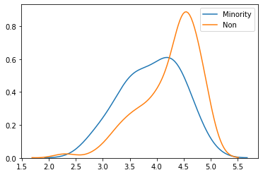

```python
sb.distplot(groups['minority'], hist=False, label='Minority')
sb.distplot(groups['not minority'], hist=False, label='Non')

plt.show()
```

### Compute SE

```python
se = np.sqrt((np.square(stds) / szs).sum())
se
```

```
0.11843068274281233
```

### Difference in means?

Looks like it is several times larger than the standard error.

### Run the t-test

```python
st.ttest_ind(groups['minority'], groups['not minority'])
```

```
Ttest_indResult(statistic=-2.8838587235552797, pvalue=0.004758351672043584)
```

### Conditions met

- Independence: presumably they were sampled well.
- Normality: n < 30, no clear outliers?, n > 30 no extreme outliers

Use `probplot`

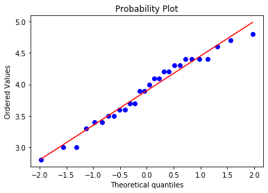

```python
ax = st.probplot(groups['minority'], dist="norm", plot=plt)
```

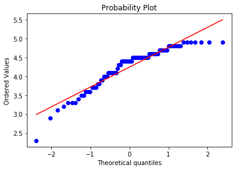

```python
ax = st.probplot(groups['not minority'], dist="norm", plot=plt)
```

### Conclusion

The lower outlier is kind of extreme, but it would tend to pull the non-minority mean lower, so if we removed it, it would not change our conclusion. Similar for the light-tail to the right: fewer high values, so a really normal distribution would show a more extreme difference.

We can reject the null hypothesis with significance level $p < 0.05$.

### Plot distribution with confidence interval

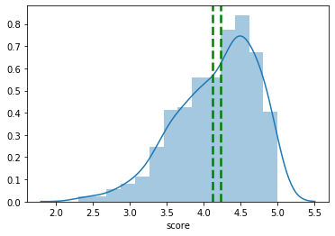

```python
sb.distplot(evals.score)
plt.axvline(x=interval[0], linestyle='--', linewidth=2.5, label="lower bound 95% CI", c='g')
plt.axvline(x=interval[1], linestyle='--', linewidth=2.5, label="upper bound 95% CI", c='g')
```

## Q3: Do tenured professors get less survey participation?

Maybe because they don't encourage students to do it. Let's look at a table of means for different groups.

```python
evals.groupby(['rank', 'gender']).agg('mean')['cls_perc_eval']
```

```
rank          gender
teaching      female    73.837384
              male      79.323725
tenure track  female    77.180253
              male      74.397220
tenured       female    76.811372
              male      71.066495
Name: cls_perc_eval, dtype: float64
```

### Male professors

They seem to be the worst

```python
evals_select = evals.query('gender=="male"')[['rank', 'score', 'cls_perc_eval']]

evals_grp = evals_select.groupby('rank')
```

```python
evals_grp.size()
```

```
rank
teaching         52
tenure track     39
tenured         177
dtype: int64
```

```python
evals_grp.mean()
```

| rank | score | cls_perc_eval |
| --- | --- | --- |
| teaching | 4.521154 | 79.323725 |
| tenure track | 4.256410 | 74.397220 |
| tenured | 4.145198 | 71.066495 |

```python
groups = evals_grp['cls_perc_eval'].apply(list)
groups
```

```
rank
teaching        [84.21053, 75.0, 93.33334, 95.65218, 90.90909,...
tenure track    [72.0, 90.90909, 95.83334, 88.23529, 92.85714,...
tenured         [85.0, 87.5, 88.63636, 100.0, 56.9230800000000...
Name: cls_perc_eval, dtype: object
```

```python
groups_lst = [lst for lst in groups]
```

### Use `f_oneway` to get the ANOVA result

```python
res = st.f_oneway(*groups_lst)
res
```

```
F_onewayResult(statistic=5.027654548780475, pvalue=0.007193231626500756)
```

### Use multicomparison to test all pairs

```python
multicomp = MultiComparison(evals_select['cls_perc_eval'], evals_select['rank'])
ans = multicomp.allpairtest(st.ttest_ind, method='bonf')
```

```python
ans[0]
```

Test Multiple Comparison ttest_ind FWER=0.05 method=bonf alphacSidak=0.02, alphacBonf=0.017

| group1 | group2 | stat | pval | pval_corr | reject |
| --- | --- | --- | --- | --- | --- |
| teaching | tenure track | 1.5169 | 0.1328 | 0.3985 | False |
| teaching | tenured | 3.2154 | 0.0015 | 0.0045 | True |
| tenure track | tenured | 1.0635 | 0.2887 | 0.8662 | False |